# Śledzie

Jan Wielebiński

01 grudzień 2016

## Podsumowanie

W wyniku przeprowadzonej analizy udało się rozwiązać zagadkę malejącej długości śledzi. Kluczowymi czynnikami okazały się być temperatura wody, oscylacja północnoatylantycka oraz dostępność planktonu.

Z punktu widzenia analizy ważne było zapoznanie się z rozkładem wartości atrybutów - pozwoliło to zrozumieć specyfikę badanego zbioru, a także wstępnie zauważyć pewne relacje oraz przewidzieć problemy które mogą się pojawić podczas przetwarzania danych. Bardzo ważne okazało się również zbadanie korelacji pomiędzy wszystkimi atrybutami - umożliwiło to wskazanie tych, które powinny mieć największy wpływ na badaną wielkość *length*.

## Wykorzystane biblioteki

```r
library(dplyr)
library(ggplot2)
library(plotly)
library(corrplot)
library(caret)
library(dprep)
library(randomForest)
```

## Dane

### Wstępna analiza

Wszystkie wielkości oraz wykresy znajdujące się w tej sekcji dotyczą zbioru po wstępnym przetworzeniu, tj. po uzupełnieniu brakujących wartości oraz usunięciu wartości odstających.

Brakujące wartości uzupełniano na podstawie jednego rekordu sąsiadującego. Zastosowano takie podejście ze względu na specyfikę zbioru danych. Rekordy są uporządkowane chronologicznie, ponadto kolejne (sąsiadujące) obserwacje były dokonywane w tym samym miejscu i czasie, a więc w tych samych warunkach. Stąd istnieje bardzo duże prawdopodobieństwo, że obserwacja sąsiadująca z badanym rekordem, dla większości atrybutów będzie posiadała te same wartości.

Analiza dotycząca wartości odstających znajduje się w sekcji *Analiza atrybutów*.

### Rozmiar zbioru

Liczba rekordów: **52576**

Liczba atrybutów: **16**

### Podstawowe statystyki

|  | X | length | cfin1 | cfin2 | chel1 | chel2 | lcop1 | lcop2 | fbar | recr | cumf | totaln | sst | sal | xmonth | nao |
| --- | --- | --- | --- | --- | --- | --- | --- | --- | --- | --- | --- | --- | --- | --- | --- | --- |
|  | Min. : 0 | Min. :19.0 | Min. :0.0000 | Min. : 0.0000 | Min. : 0.000 | Min. : 5.238 | Min. : 0.3074 | Min. : 7.849 | Min. :0.0680 | Min. : 140515 | Min. :0.06833 | Min. : 144137 | Min. :12.77 | Min. :35.40 | Min. : 1.000 | Min. :-4.89000 |
|  | 1st Qu.:13144 | 1st Qu.:24.0 | 1st Qu.:0.0000 | 1st Qu.: 0.2778 | 1st Qu.: 2.469 | 1st Qu.:13.427 | 1st Qu.: 2.5479 | 1st Qu.:17.808 | 1st Qu.:0.2270 | 1st Qu.: 360061 | 1st Qu.:0.14809 | 1st Qu.: 306068 | 1st Qu.:13.60 | 1st Qu.:35.51 | 1st Qu.: 5.000 | 1st Qu.:-1.89000 |
|  | Median :26288 | Median :25.5 | Median :0.1111 | Median : 0.7012 | Median : 5.750 | Median :21.435 | Median : 7.0000 | Median :24.859 | Median :0.3320 | Median : 421391 | Median :0.23191 | Median : 539558 | Median :13.86 | Median :35.51 | Median : 8.000 | Median : 0.20000 |
|  | Mean :26288 | Mean :25.3 | Mean :0.4421 | Mean : 2.0245 | Mean : 9.998 | Mean :21.216 | Mean :12.7910 | Mean :28.420 | Mean :0.3304 | Mean : 520247 | Mean :0.22982 | Mean : 514949 | Mean :13.88 | Mean :35.51 | Mean : 7.257 | Mean :-0.09225 |
|  | 3rd Qu.:39431 | 3rd Qu.:26.5 | 3rd Qu.:0.3333 | 3rd Qu.: 1.7936 | 3rd Qu.:11.500 | 3rd Qu.:27.193 | 3rd Qu.:21.2315 | 3rd Qu.:37.232 | 3rd Qu.:0.4582 | 3rd Qu.: 724151 | 3rd Qu.:0.29803 | 3rd Qu.: 730351 | 3rd Qu.:14.16 | 3rd Qu.:35.52 | 3rd Qu.: 9.000 | 3rd Qu.: 1.63000 |
|  | Max. :52581 | Max. :32.5 | Max. :4.8333 | Max. :19.3958 | Max. :75.000 | Max. :57.706 | Max. :75.0000 | Max. :68.736 | Max. :0.8490 | Max. :1380210 | Max. :0.39801 | Max. :1015595 | Max. :14.73 | Max. :35.61 | Max. :12.000 | Max. : 5.08000 |

### Analiza atrybutów

Na podstawie rozkładu atrybutów zdecydowano się na usunięcie rekordów dla których wartość atrybutu *cfin1* przekracza *37.00*, a dla *lcop1* wartość *115.00*. Z analizy pliku źródłowego wynika, że 6 kolejnych rekordów w przypadku obu tych atrybutów posiada wartości, które znacznie odbiegają od rozkładu zmiennej. Ze względu na niewielką liczbę takich rekordów oraz wysokie prawdopodobieństwo, że wartości tych atrybutów są błędne, zdecydowano o ich odrzuceniu z badanego zbioru.

W przypadku pozostałych atrybutów nie zaobserwowano tak znacznych anomalii. Rozważano możliwość odrzucenia pewnych rekordów ze względu na obecność odbiegających wartości dla atrybutów *cfin2*, *chel1*, *chel2* czy *lcop1*. Jednak liczba takich rekordów była już znaczna, co pozwala podejrzewać że anomalia jest rzeczywistym zjawiskiem, a nie wynika z błędu ludzkiego.

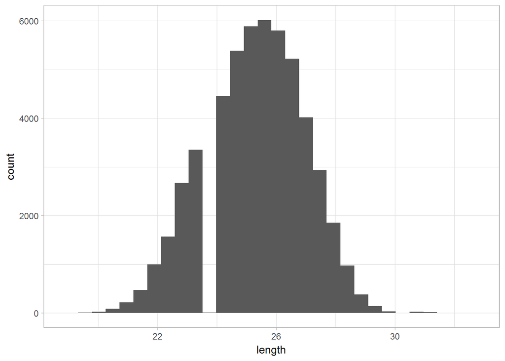

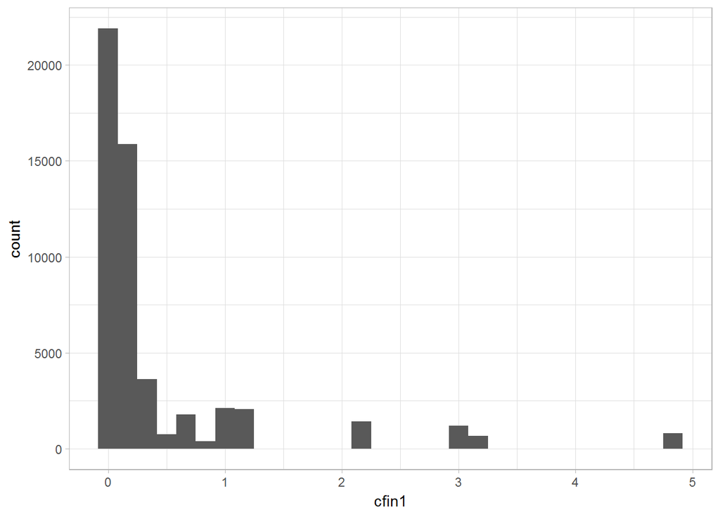

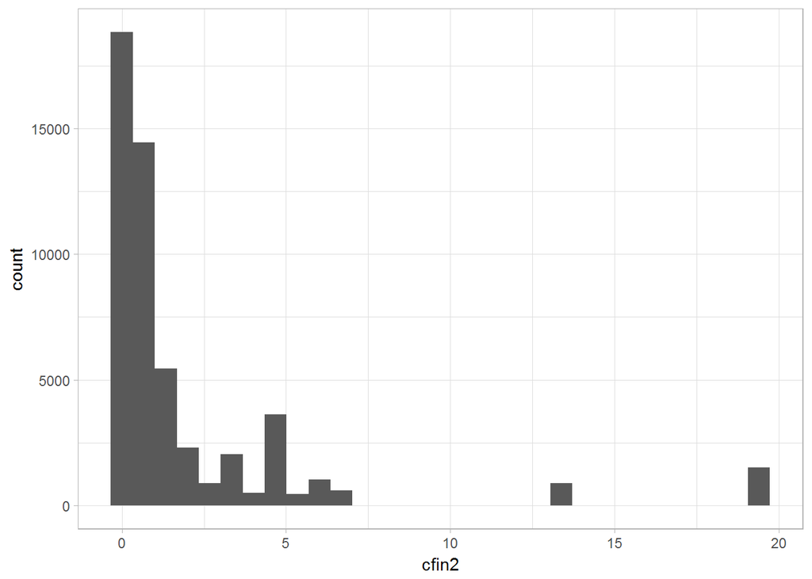

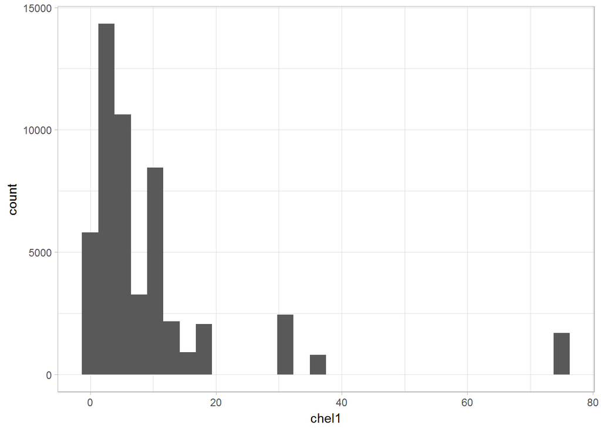

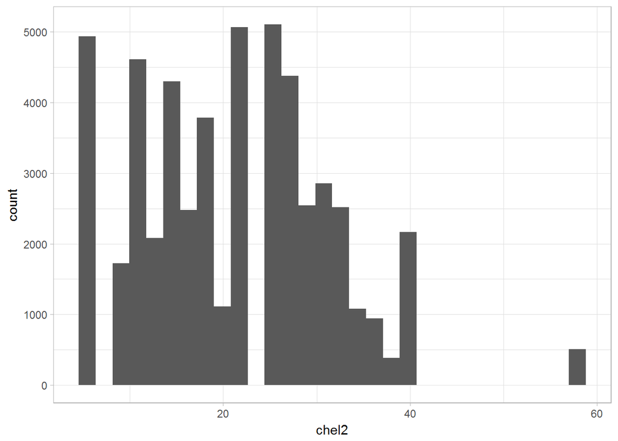

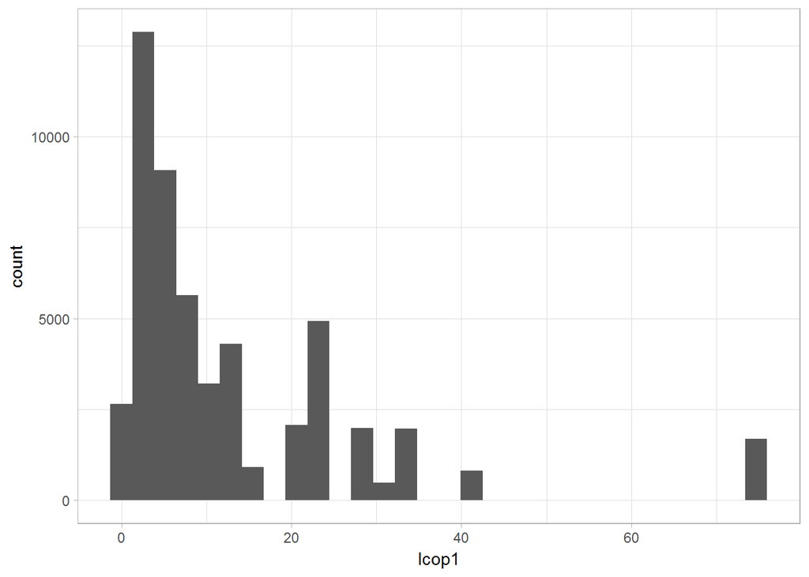

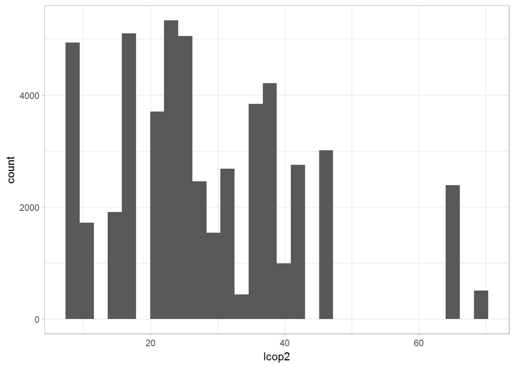

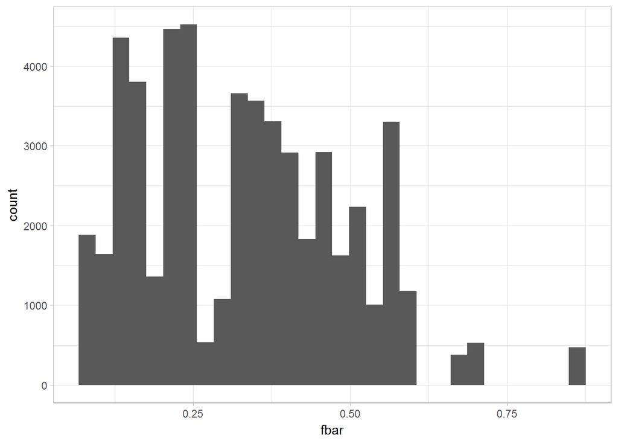

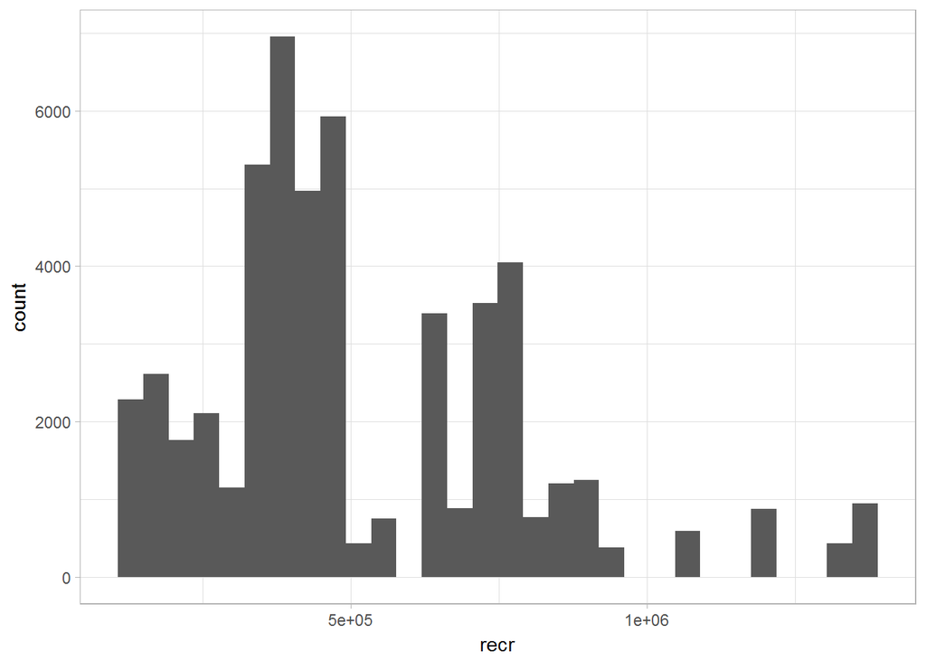

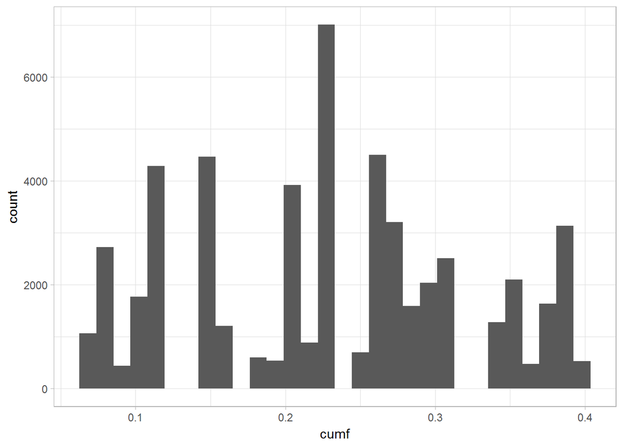

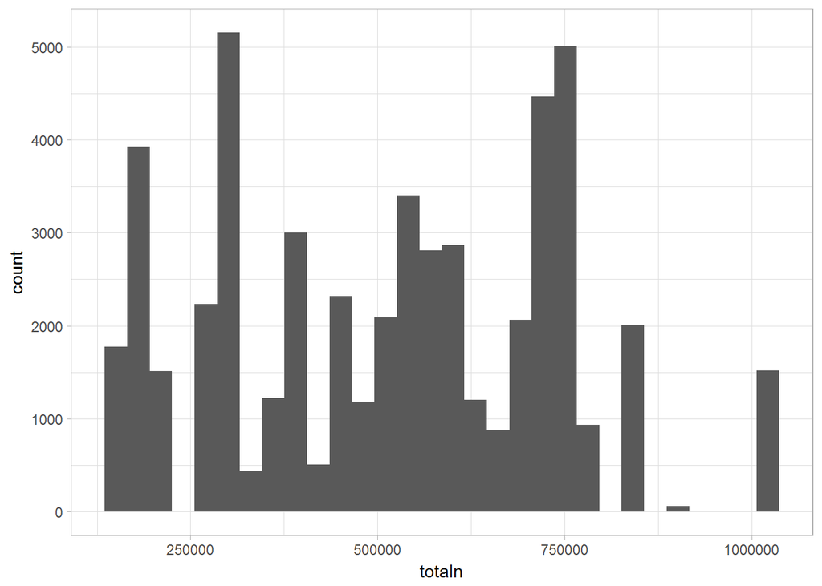

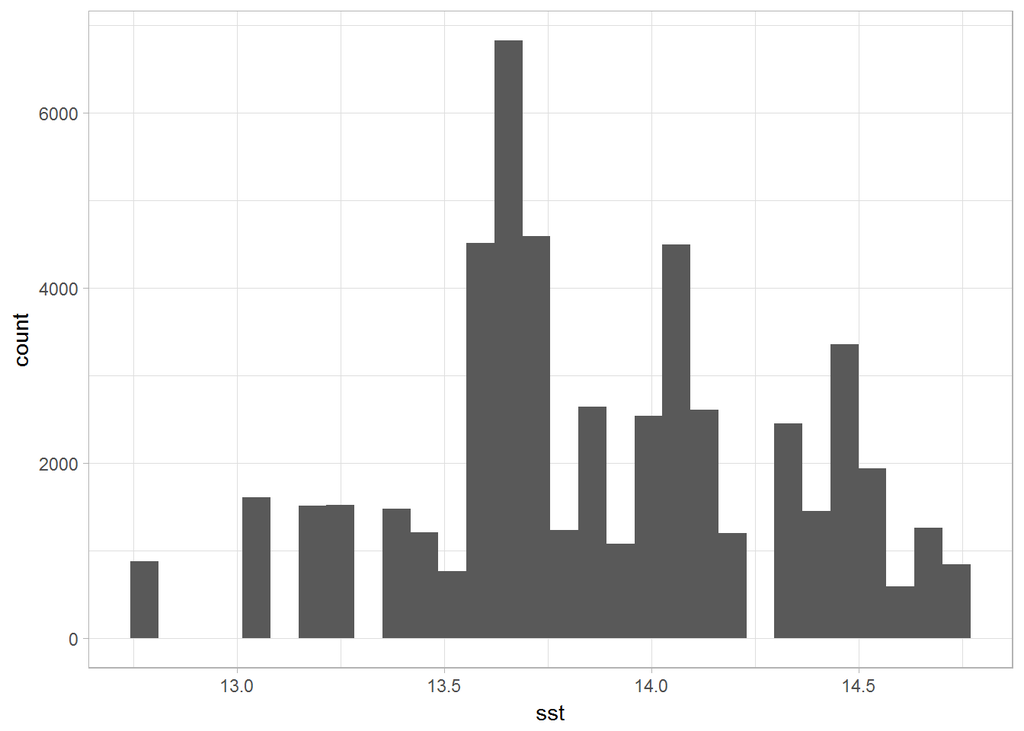

[3 more figures not shown]

### Korelacje

Na podstawie wykresu prezentującego korelacje między wszystkimi atrybutami, można zauważyć że atrybut *length* jest najsilniej ujemnie skorelowany z atrybutami *sst* oraz *nao*, a także najsilniej dodatnio skorelowany z atrybutami *fbar*, *chel1* oraz *lcop1*. Na tym etapie warto również zauważyć, że atrybuty *chel1* oraz *lcop1* są ze sobą bardzo silnie skorelowane.

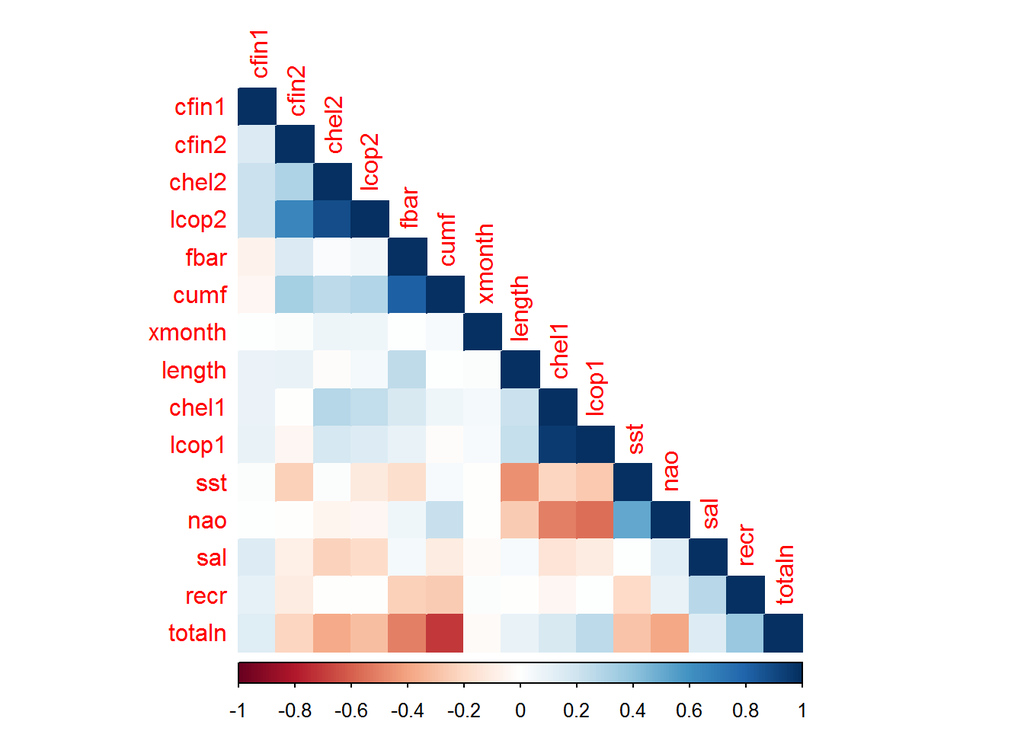

## Wykres zmiany długości śledzia w czasie

[interactive chart not shown]

## Regresor

### Normalizacja danych

Wszystkie atrybuty z wyjątkiem *length* poddano normalizacji metodą *Min-Max* do przedziału [0, 1], ponieważ podczas testów niektóre z metod wymagały takiego przygotowania danych.

### Przygotowanie

Znormalizowane dane podzielono na zbiór uczący i testowy w proporcji *75%-25%*. Jako atrybut podlegający stratyfikacji wybrano *length*. W trakcie uczenia zastosowano krzyżową walidację z podziałem na *3* podzbiory.

### Przetestowane metody

Podczas tworzenia raportu przetestowano 3 metody regresji:

- Linear regression,
- Support Vector Machines with Linear Kernel,
- Random forest.

*Linear regression* nawet przy wykorzystaniu wszystkich atrybutów gwarantował *RMSE = 1.36* oraz *RSquared = 0.32*. *SVM* osiągnął nieco gorszy wynik: *RMSE = 1.43* oraz *RSquared = 0.24*. Powyższe metody nie zapewniały satysfakcjonujących rezultatów. Zdecydowanie najlepiej sprawdził się *Random forest* opisany w kolejnym punkcie.

Dla metod *SVM* oraz *Random forest* należało dokonać selekcji atrybutów, które tworzą model, ze względu na długi czas jego budowy. Wyboru dokonano na podstawie obserwacji korelacji między atrybutami w badanym zbiorze. Wybrano atrybuty *sst*, *nao*, *fbar* oraz *lcop1*. Nie wybrano dość silnie skorelowanego atrybutu *chel1*, ponieważ jest on bardzo silnie skorelowany z *lcop1* (*0.8830089*), więc nie ma potrzeby by również był obecny w modelu.

### Wyniki

```
## Random Forest
##
## 39433 samples
##     4 predictor
##
## No pre-processing
## Resampling: Cross-Validated (3 fold)
## Summary of sample sizes: 26288, 26289, 26289
## Resampling results across tuning parameters:
##
##   mtry  RMSE      Rsquared
##   2     1.188558  0.4840704
##   3     1.188585  0.4840510
##   4     1.188909  0.4837717
##
## RMSE was used to select the optimal model using  the smallest value.
## The final value used for the model was mtry = 2.
```

Podczas predykcji wartości w zbiorze testowym uzyskano *RMSE* na poziomie: **1.1851204**.

Natomiast wskaźnik *RSquared* wyniósł: **0.4824133**.

### Analiza ważności atrybutów

Najlepszy znaleziony model tworzą atrybuty *sst*, *nao* oraz *lcop1*. Można więc wysnuć wniosek, że rozmiar śledzi zaczął maleć ze względu na rosnącą temperaturę przy powierzchni wody, wzrastającą oscylację północnoatlantycką oraz spadającą dostępność planktonu. Na poniższych wykresach widać zbieżność zmiany tych czynników ze zmianą długości śledzia.

Szczególnie warto zwrócić uwagę na fakt, że w czasie gdy odnotowano największą długość śledzia (między 1965, a 1980 rokiem), wszystkie atrybuty określone jako ważne również osiągały swoje ekstrema. Potwierdza to słuszność ich wyboru.

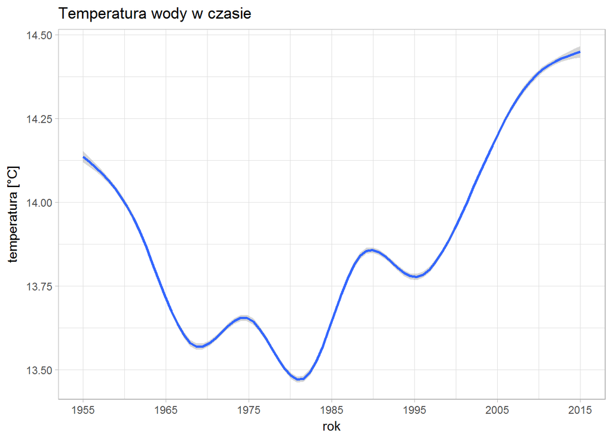

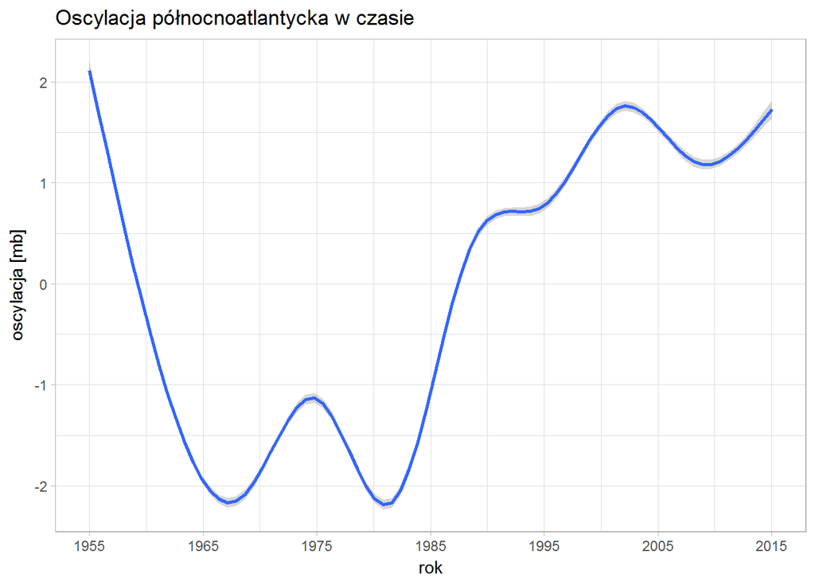

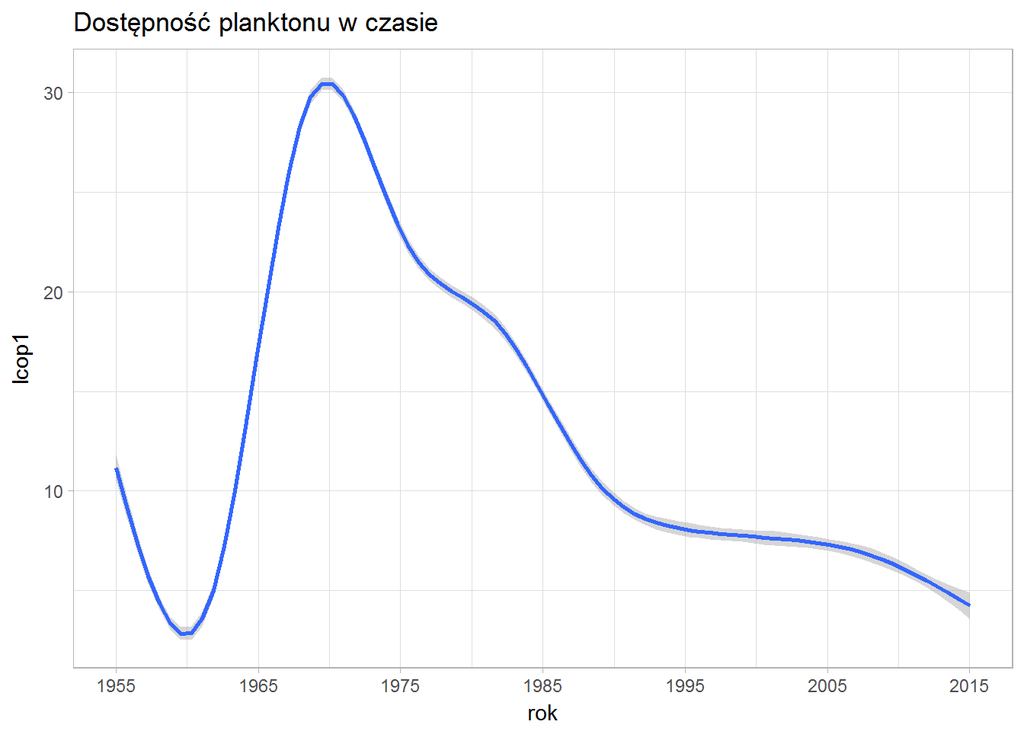